# Final Project

Clayton Rawson

## [Home](https://crawson1987.github.io) | [About Me](https://crawson1987.github.io/About_Me) | CV | [Final Project](https://crawson1987.github.io/Final_Project/Final_Project)

# A Quatitative and Statistical Analysis of a Previous Published Paper on Parkinson’s Disease and the Gut Mycobiome

## Introduction

The goal of this research was to analyze the metadata from a recently published paper by using various statistical methods as well as charts and plots. The goal was to get an more complete view of the data and the interpretations that could be made from it. The research paper that I will be using is titled “The Gut Mycobiome in Parkinson’s Disease.” The paper was published in February of 2021 in the Journal of Parkinson’s Disease (vol. 11, no.1, pp. 152-158) by Mihai S. Cirstea, Kristen Sundvick, Ella Golz, Adam C. Yu, Rozlyn C. T. Boutin, Daniel Kliger, Brett B. Finlay, and Silke Appel-Cresswell.

## Data Analysis

The first step in my analysis look at the data and see what the data looked like. The following chart looked at the number of samples per OTU.

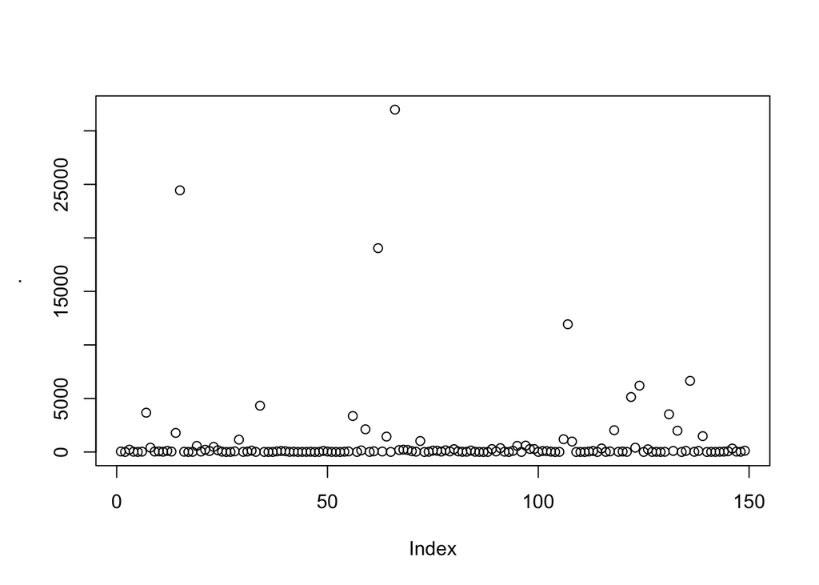

From the chart above we can see that a lot of the samples are clustered at the bottom with not a lot taxonomic units with a high number of samples. There are a few that have much higher numbers, above 10000, but most of them are low with values much less than 5000.

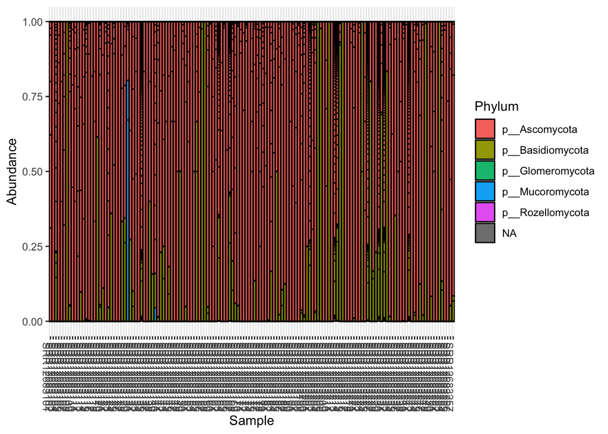

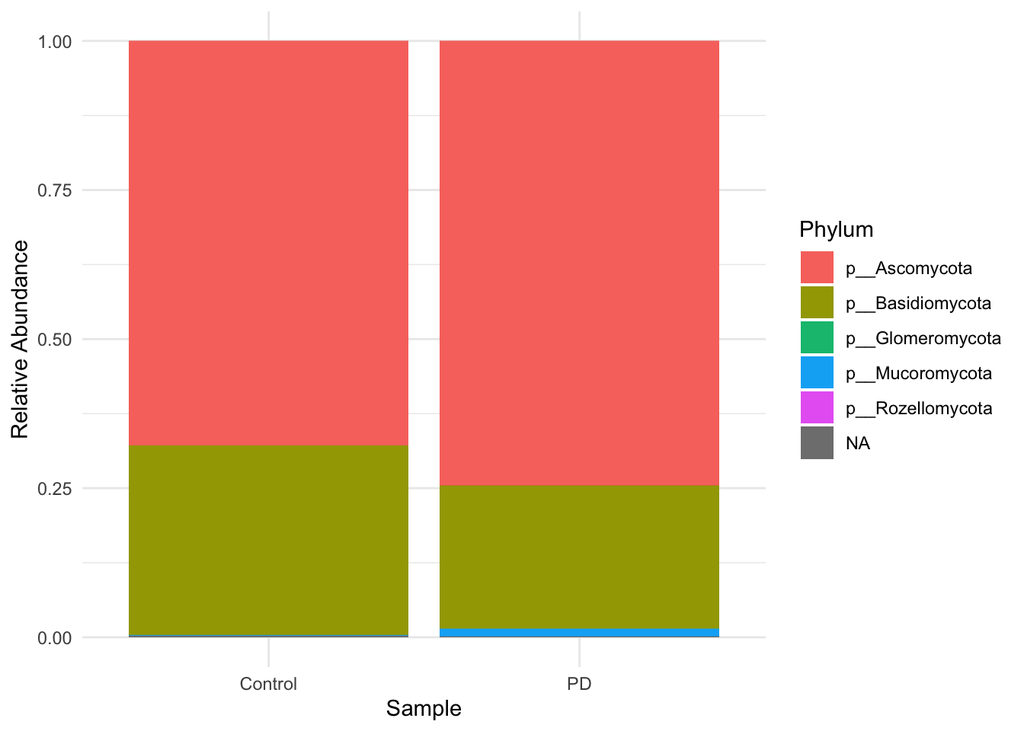

The graph and chart above both helped me learn more about the metadata that the paper was working with. In terms of the chart, I found what I was expecting. The data is not very diverse in both the control and the PD groups. The phylum level data looked reasonable. A saw the basic phyla that I was expecting to see. All of the main fungal phyla were present in numbers that I could see as reasonable.

### Class Level Data

I decided that I wanted to next see the class level data and see how it compared to the diversity I was seeing in the phylum level.

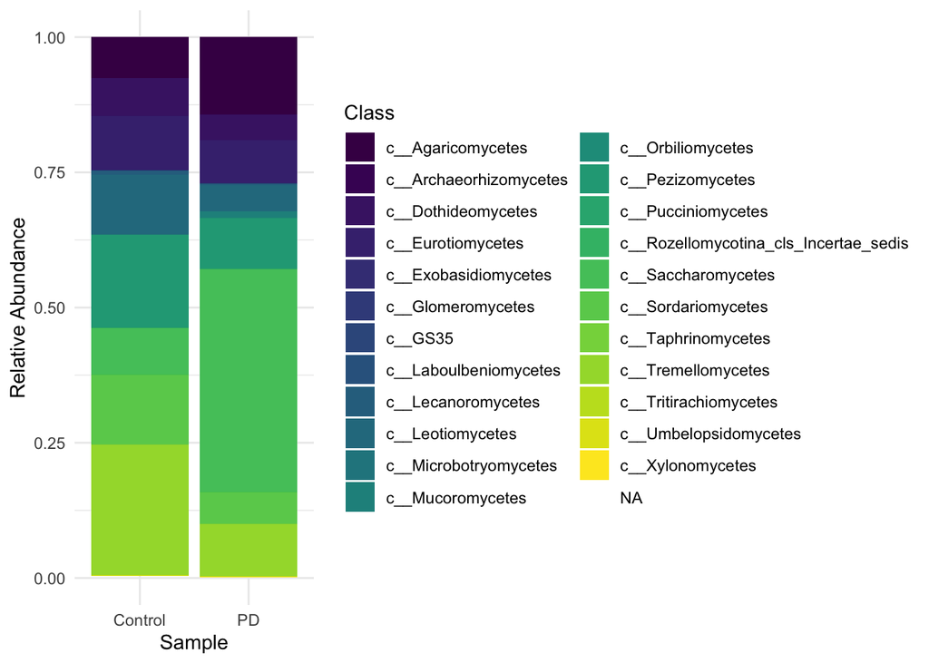

### Alpha Diversity

I decided to start with alpha diversity, which is the mean diversity of a species in a single sample. Hopefully, by by looking at this kind of diversity I can see how diverse each of the samples are.

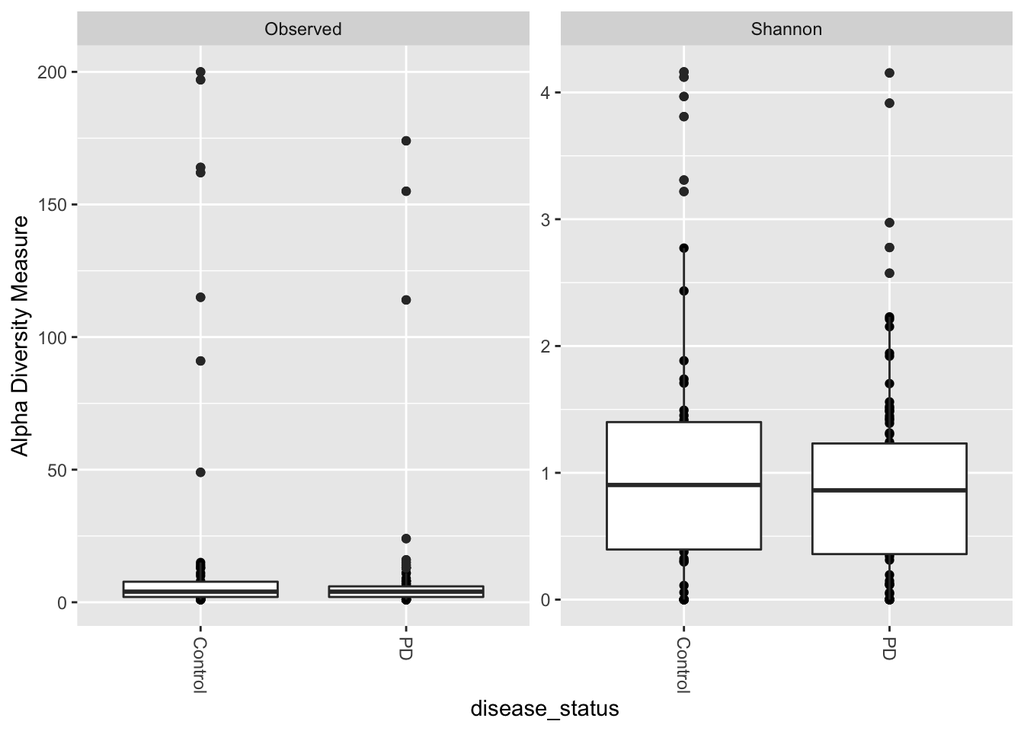

The alpha diversity seen above showed that a lot of the samples are clustered near each other with some diversity being found near the 50, 100, 150, and 200 mark. The data and graph above show that the diversity of the samples is not that high. Since Shannon Diversity is a type of alpha diversity I put it hear, but I will discuss it more later.

### Beta Diversity

After looking at alpha diversity I decided to look at beta diversity, which is a ratio or comparison between two different samples. This allows one to see how two groups compare to one another. By doing this I can see how the control group compares to the PD group.

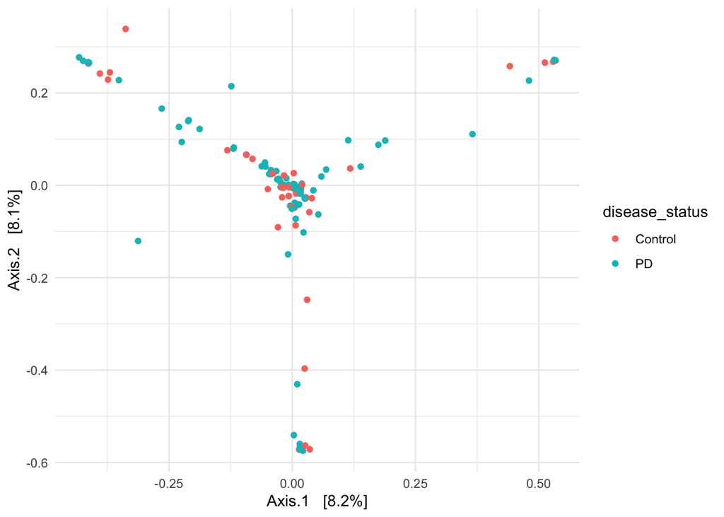

Based on what I have seen so far I was not expecting the beta diversity to be any different then what I had seen so far. The data above shows that the control and PD have vary similar values on the graph, which is why they are grouped together most of the time. There are a few areas that have outliers with just control or PD, but for the most part they seemed to be near to each other. This shows that the diversity between samples is not much better then the diversity of the samples themselves.

### Categorical Comparison of BMI, sex, and disease status

Continuing with the idea of beta beta diversity I decided to compare several of the variables that the study was looking at. The one I choose where BMI, sex, and how those related to disease status.

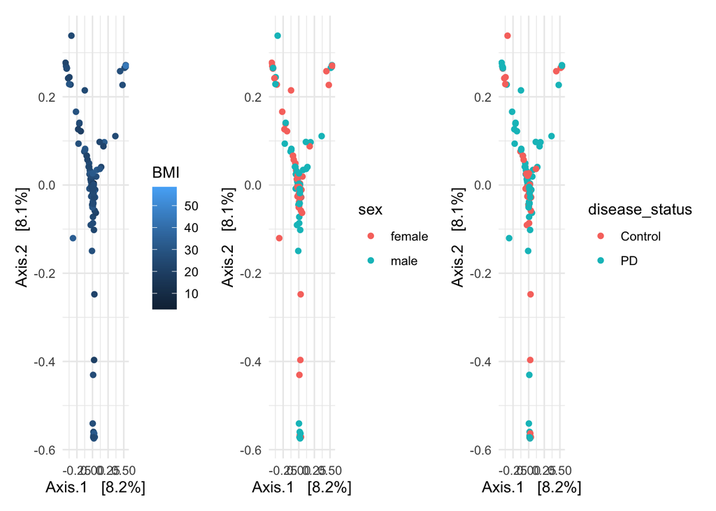

I had hopped that by looking at the specific areas of their data I might be able to learn more about how the groups compared. From what I can see from the three graphs above data from BMI, sex, and disease all look very similar. This to me is the reflection of the lack of diversity stemming from a sample size with few OTUs.

### Shannon Diversity

Finally, I decided to look at Shannon diversity index, which looks the number of species in a sample, which is known as richness, and the relative abundance, which is known as evenness. This diversity index is a quantitative indicator that can be used to see how rich in numbers a species is. Shannon diversity is measure of alpha diversity.

In order to look at the Shannon Diversity properly I decided to look at in both a plot and in a table form with numerical values representing the data.

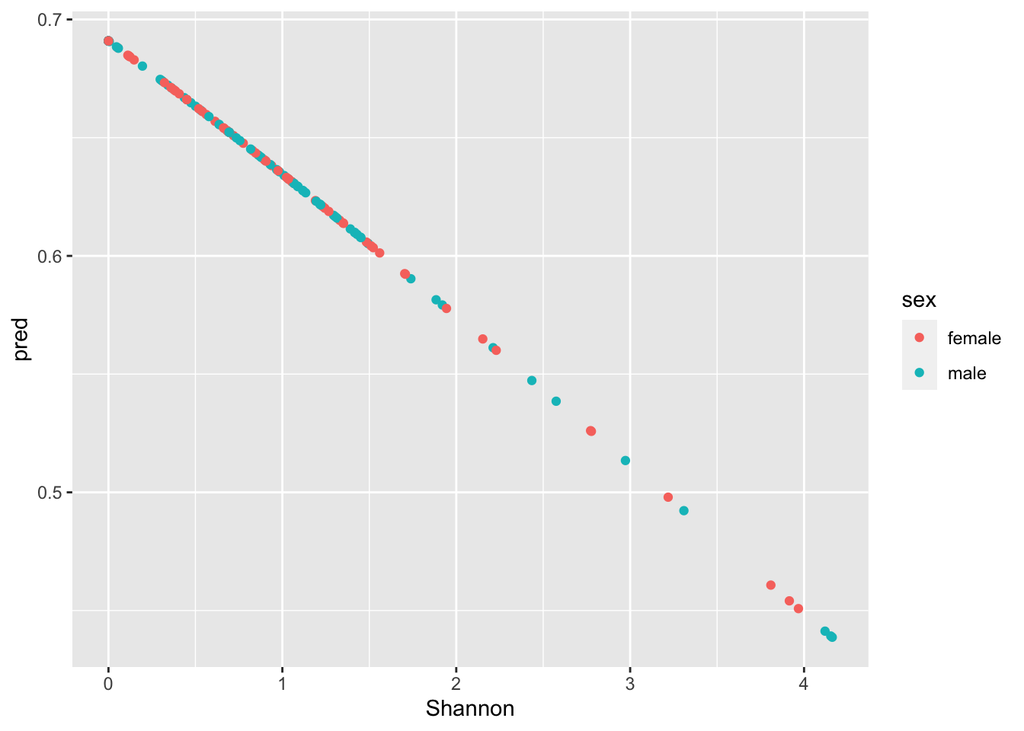

```
##
## Call:
## glm(formula = disease_status ~ Shannon, family = "binomial",
##     data = fung@sam_data %>% as("data.frame"))
##
## Deviance Residuals:
##     Min       1Q   Median       3Q      Max
## -1.5324  -1.3838   0.8734   0.9590   1.2828
##
## Coefficients:
##             Estimate Std. Error z value Pr(>|z|)
## (Intercept)   0.8044     0.2556   3.147  0.00165 **
## Shannon      -0.2525     0.1799  -1.403  0.16061
## ---
## Signif. codes:  0 '***' 0.001 '**' 0.01 '*' 0.05 '.' 0.1 ' ' 1
##
## (Dispersion parameter for binomial family taken to be 1)
##
##     Null deviance: 193.31  on 146  degrees of freedom
## Residual deviance: 191.33  on 145  degrees of freedom
## AIC: 195.33
##
## Number of Fisher Scoring iterations: 4
```

## Conclusions

After a thorough look at the metadata from this paper I feel that I still have some things I would like to learn, but I do feel that I have learned a lot already. At the start of this research project I wanted to take a more in depth look at the metadata and find if the conclusions that the research paper had found were correct.